# Factors that influence the IMDb rating of a movie

## Investigation Overview

This project attempts to identify the characteristics that influence the IMDb rating of a movie, with focus on features like *Genre* of the movie, *Year of production* of the movie and *Movie Runtime*.

## Dataset Overview

Dataset for this prject has been obtained from Kaggle. The dataset initially consisted of 16744 movies,however 502 rows and several columns had to be dropped due to data inconsistencies and missing data.The dataset consists of several features like *Title of the Movie,Year of Production,Genres* and *IMDb ratings*.

```python
# import all packages and set plots to be embedded inline
import numpy as np
import pandas as pd
import matplotlib.pyplot as plt
import seaborn as sns

%matplotlib inline

# suppress warnings from final output
import warnings
warnings.simplefilter("ignore")
```

```python
# load in the wrangled dataset into a pandas dataframe
movies = pd.read_csv('movies.csv')
```

##### All the following visualizations have directly been imported and the code for them can be found in the Jupyter Notebook.

## Distribution of the Year column

The **Year** column contains the year in which the movie was produced.The following plot shows us that the distribution of this variable is left-skewed.This means that the OTT platforms in our dataset prefer to showcase relatively newer movies.Highest number of movies in our dataset were produced in the year 2017.Our dataset consists of several movies that were produced between the years **1902** and **2020**.

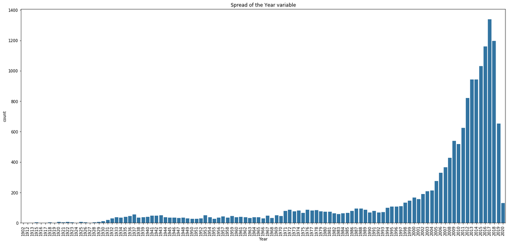

## Distribution of the IMDb ratings

The IMDb ratings of the movies in our dataset seem to have a *normal distribution* with a peak of **5.9** .More than 700 movies in our dataset have IMDb rating of 5.9 .Majority of the movies are clustered between the ratings **5.3** and **7.3** . Very few movies have a rating greater than **9** and less than **1.5** .

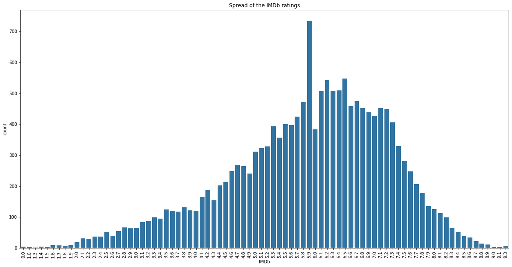

## IMDb rating vs Year of Production

Multiple plots(Heatmap and correlation heatmap) can be seen in the following slides.The first heatmap shows the **relationship between the two numeric variables** and the second heatmap shows us the **correlation** between them.The white spots on the heatmap indicate that there were very few or no movies produced satisfying the corresponding criteria of IMDb rating and Year of Production.The highest populous cluster of films is between the period 2015-2019 with the rating between 5.75 and 7.5.There is no obvious trend visible in the heatmap.The correlation heatmap shows that there is a **weak negative correlation** between the IMDb and Year variables(**-0.024**).This confirms our observation that the IMDb rating of the movie is **not/barely** affected by its year of production.

[figure not shown]

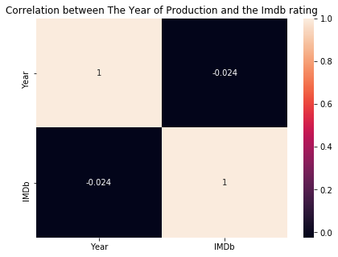

## IMDb rating vs runtime of the movie

Multiple plots(Heatmap and correlation heatmap) can be seen in the following slides.The first heatmap shows the **relationship between the two numeric variables** and the second heatmap shows us the **correlation** between them..The white spots on the heatmap indicate that there were very few or no movies produced satisfying the corresponding criteria of IMDb rating and teh runtime of the movie.Majority of the movies are clustered in the region with runtime around 100 minutes and IMDb rating between 5.5-7.5 .There are no movies with runtime more than 200 minutes and IMDB rating less than 4.It appears as if there is no general trend between the runtime of the movie and its IMDb rating.The correlation heatmap tells us that there is a weak positive correlation between the IMDb rating of the movie and its runtime(**0.09**).This confirms our observation from the initial heatmap that the IMDb rating of a movie is **not/barely** affected by its runtime.

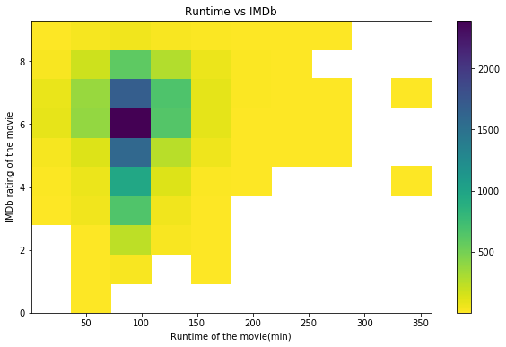

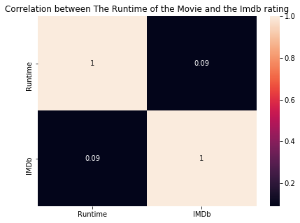

## IMDb rating vs Various OTT platforms

The following slide has a correlation heatmap that gives us the **correlation** between various **OTT** platforms and the **IMDb** ratings of a movie.It gives us the correlation among the **OTT** platforms aswell.There is **weak positive correlation** between Netflix and IMDb rating(**0.14**), that is if a movie is offered by Netflix, it has a weak postive effect on its IMDb rating.There is **weak negative correlation** between Prime Video and IMDb rating(**-0.16**), that is if a movie is offered by Prime Video, it has a weak negative effect on its IMDb rating.Both Hulu and Disney+ have a very **weak positive correlation** with the IMDb rating of a movie offered by them(**0.04** and **0.08**),thus it has a negligible effect on the movie's IMDb rating.There is a **strong negative correlation** between Netflix and Prime Video(-0.75), that is if a movie is offered by one of the two platforms,it is **highly unlikely** that the other platform will offer the same movie.To generalize, all the OTT platforms have a **negative correlation** with each other(weak or strong).

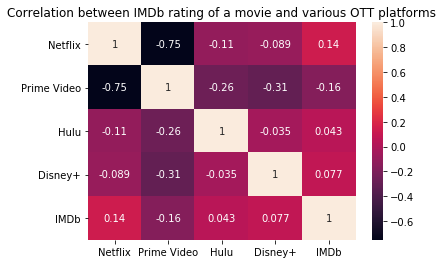

## IMDb vs Year vs Country

Only the movies produced in **U.S.A**, **U.K** and **India** have been considered for the following plot.These plots have been obtained using **faceting**. We can see that **majority** of the movies have been produced in **United States**.The number of movies produced in **India** has **significantly increased** in the **21st century**.There are very few movies from **United Kingdom** with a low rating(**<2**).There are even less movies from **India** with a low rating(**<2**).Despite segregating the movies with their country of production, no concrete trend could be found between the IMDb rating of a movie and its Year of Production.This further proves our previous observation that the **IMdb** rating is **not significantly affected** by its year of production.

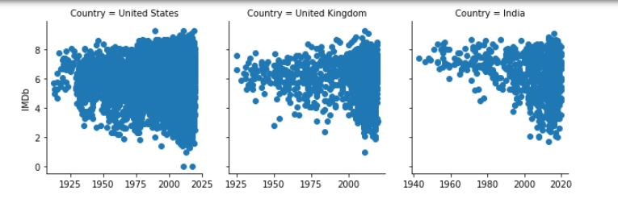

## IMDb vs Genres vs Year

Only few of the genres have been considered for the following plots.These plots have been obtained by using **faceting**. We can see that all the plots follow a similer trend, that is **majority** of the films across all the above genres have been produced in the **21st** century.There is **no general trend** between the **IMDb rating** of the movie and its **Year of production** even when the movies are separated by their genres.This further proves our previous observation that the **IMdb** rating is **not significantly affected** by its year of production.

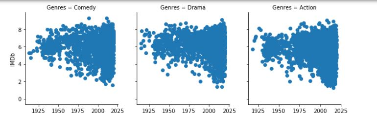

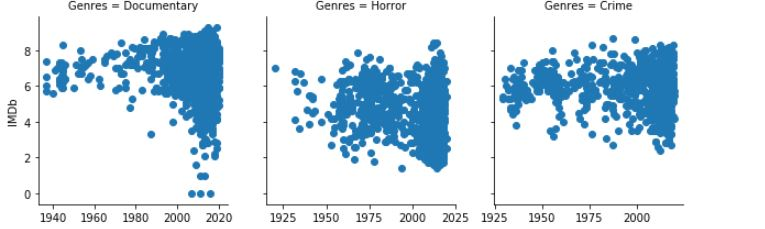

[figure not shown]

### IMDb vs Runtime vs Country

Only the movies produced in **U.S.A**, **U.K** and **India** have been considered for the following plot.These plots have been obtained using **faceting**. We can observe that, movies in India generally have a **greater average runtime** than **U.S** and **U.K**.Movies from UK generally have a **runtime less than 200 minutes**.Despite **segregating** the movies with respect to their **country of production**, no concrete trend could be found between the Runtime and IMDb features of our dataset.This further proves our previous observation that the **IMdb** rating is **not significantly affected** by its runtime.

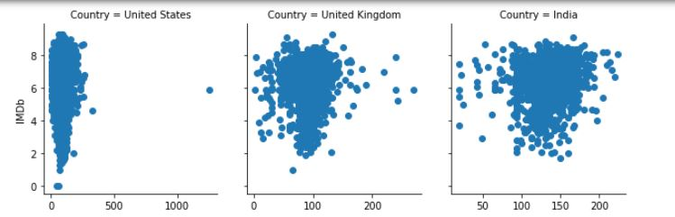

### IMDb vs Runtime vs Genres

Only few of the genres have been considered for the following plots.These plots have been obtained by using **faceting**. We can observe that **majority** of the movies have a runtime **less than 200 minutes**.There are some outliers(in the action genre) with a **runtime of more than 500 minutes**. Despite **segregating** the movies with respect to their **genres**, no concrete trend could be found between the Runtime and IMDb features of our dataset.This further proves our previous observation that the **IMdb** rating is **not significantly affected** by its runtime.

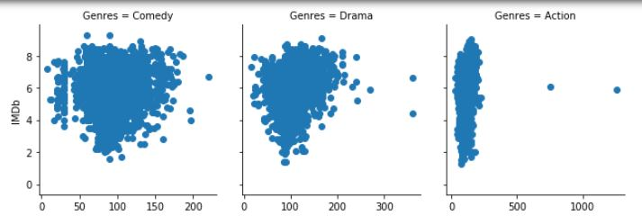

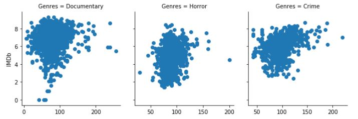

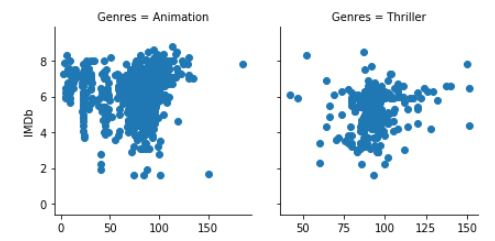

## Conclusion:

- **There is no feature in our dataset that significantly affects the IMDb rating of a movie.**
- **Netflix and Prime Video have the highest positive and negative correlation(0.14 and -0.16) with the IMDb column.**
- **There is strong negative correlation between the availability of a movie on Netflix and Prime Video.**